# tugas prak 1-mpdw

najwafach

2026-08-26

```r
library("forecast")
```

```r
library("graphics")
library("TTR")
library(TSA)
```

# Impor Data

```r
library(rio)
data1 <- import("https://raw.githubusercontent.com/najwafach/mpdw/refs/heads/main/pertemuan%201/MPDW%20Cabai%20merah.csv")

head(data1)
```

```
##     Komoditas    Tanggal Harga
## 1 Cabai Merah 04/01/2021  57,5
## 2 Cabai Merah 05/01/2021 57,35
## 3 Cabai Merah 06/01/2021 56,35
## 4 Cabai Merah 07/01/2021  55,9
## 5 Cabai Merah 08/01/2021  54,9
## 6 Cabai Merah 11/01/2021 52,85
```

# Eksplorasi Data

```r
View(data1)
str(data1)
```

```
## 'data.frame':    1294 obs. of  3 variables:
##  $ Komoditas: chr  "Cabai Merah" "Cabai Merah" "Cabai Merah" "Cabai Merah" ...
##  $ Tanggal  : chr  "04/01/2021" "05/01/2021" "06/01/2021" "07/01/2021" ...
##  $ Harga    : chr  "57,5" "57,35" "56,35" "55,9" ...
```

```r
dim(data1)
```

```
## [1] 1294    3
```

mengubah format data

```r
data1$Harga <- as.numeric(
  gsub(",", ".", data1$Harga)
)
```

```r
data1$Tanggal <- as.Date(
  data1$Tanggal,
  format = "%d/%m/%Y"
)
```

```r
head(data1)
```

```
##     Komoditas    Tanggal Harga
## 1 Cabai Merah 2021-01-04 57.50
## 2 Cabai Merah 2021-01-05 57.35
## 3 Cabai Merah 2021-01-06 56.35
## 4 Cabai Merah 2021-01-07 55.90
## 5 Cabai Merah 2021-01-08 54.90
## 6 Cabai Merah 2021-01-11 52.85
```

mengambil 100 baris data yang digunakan

```r
data2 <- data1[201:300, ]
```

```r
head(data2)
```

```
##       Komoditas    Tanggal Harga
## 201 Cabai Merah 2021-10-14 34.85
## 202 Cabai Merah 2021-10-15 34.70
## 203 Cabai Merah 2021-10-18 34.20
## 204 Cabai Merah 2021-10-19 34.30
## 205 Cabai Merah 2021-10-20 51.25
## 206 Cabai Merah 2021-10-21 34.40
```

```r
tail(data2)
```

```
##       Komoditas    Tanggal Harga
## 295 Cabai Merah 2022-02-23 47.05
## 296 Cabai Merah 2022-02-24 47.45
## 297 Cabai Merah 2022-02-25 48.00
## 298 Cabai Merah 2022-03-01 50.10
## 299 Cabai Merah 2022-03-02 50.80
## 300 Cabai Merah 2022-03-04 51.85
```

```r
nrow(data2)
```

```
## [1] 100
```

mengubah data menjadi time series

```r
data2.ts <- ts(data2$Harga)
```

```r
data2.ts
```

```
## Time Series:
## Start = 1
## End = 100
## Frequency = 1
##   [1] 34.85 34.70 34.20 34.30 51.25 34.40 34.75 35.45 35.40 35.35 35.35 35.55
##  [13] 36.10 36.10 36.50 37.10 38.10 39.65 40.45 41.70 41.35 41.50 41.90 41.85
##  [25] 42.00 41.75 41.60 42.00 42.10 41.80 42.05 42.30 42.55 42.80 43.20 43.60
##  [37] 44.30 46.65 47.20 48.00 48.55 49.90 51.45 51.75 50.85 51.80 51.60 50.75
##  [49] 50.70 50.75 50.35 50.65 51.25 51.00 50.30 49.15 48.65 47.50 47.05 46.45
##  [61] 45.60 44.55 42.75 41.45 40.75 39.90 39.55 39.70 39.75 39.90 39.95 39.65
##  [73] 39.30 39.20 38.65 38.75 38.80 38.05 19.00 38.00 37.80 37.35 38.65 39.10
##  [85] 39.70 40.00 40.45 42.60 43.05 43.45 43.65 43.35 45.30 46.10 47.05 47.45
##  [97] 48.00 50.10 50.80 51.85
```

```r
summary(data2.ts)
```

```
##    Min. 1st Qu.  Median    Mean 3rd Qu.    Max.
##   19.00   39.02   41.95   42.61   47.26   51.85
```

Membuat plot deret waktu

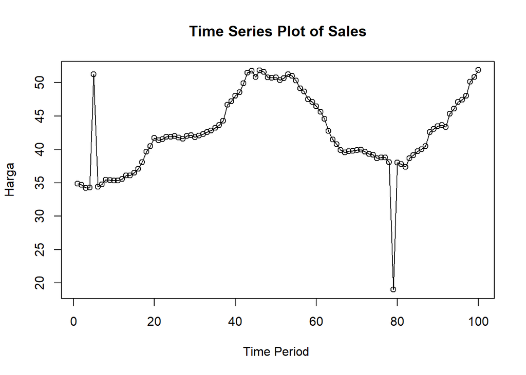

```r
ts.plot(data2.ts, xlab="Time Period ", ylab="Harga",
        main = "Time Series Plot of Sales")
points(data2.ts)
```

# Single Moving Average & Double Moving Average

## Pembagian Data

Pembagian data latih dan data uji dilakukan dengan perbandingan 80% data latih dan 20% data uji.

```r
# hitung jumlah data
n <- nrow(data2)

# tentukan batas 80%
n_train <- floor(0.8 * n)

# bagi data
training_ma <- data2[1:n_train, ]
testing_ma  <- data2[(n_train+1):n, ]

# ubah ke time series
train_ma.ts <- ts(training_ma$Harga)
test_ma.ts  <- ts(testing_ma$Harga)
```

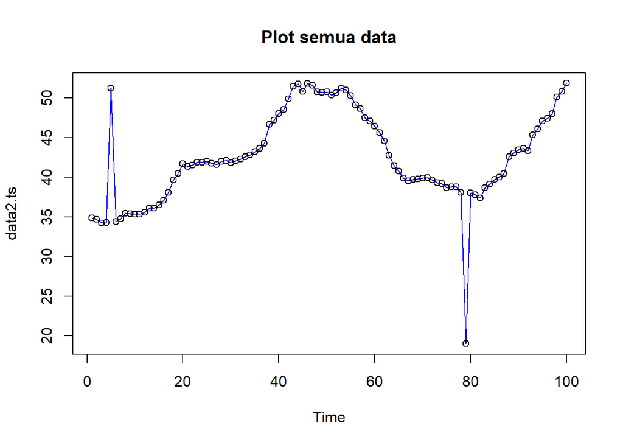

```r
#eksplorasi keseluruhan data
plot(data2.ts, col="blue",main="Plot semua data")
points(data2.ts)
```

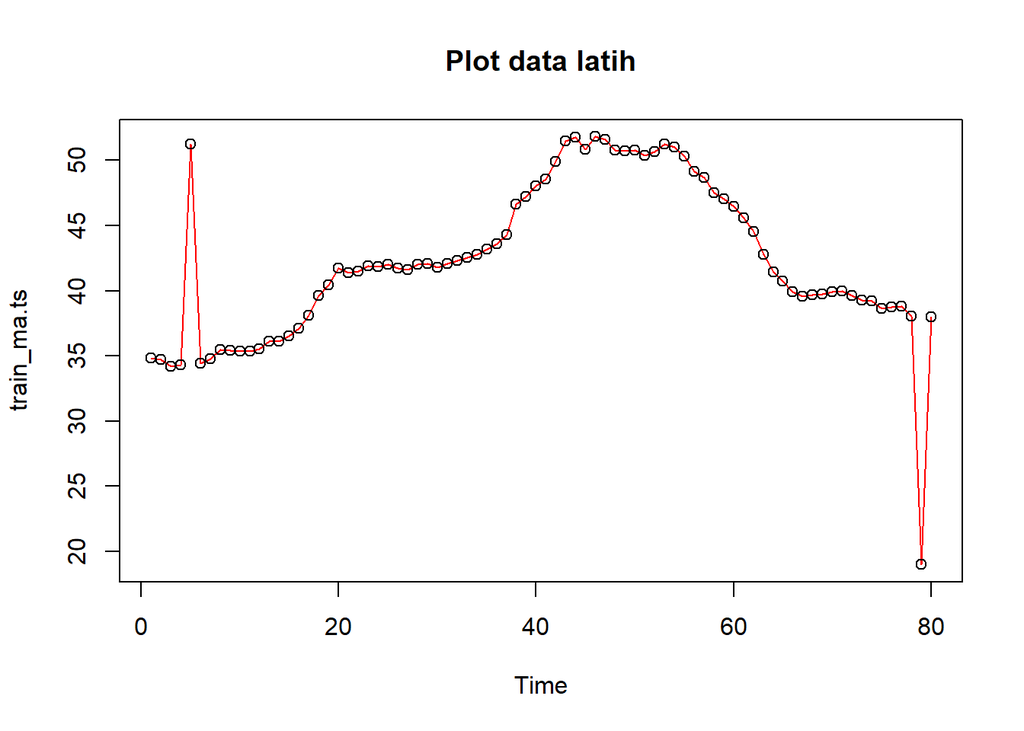

```r
#eksplorasi data latih
plot(train_ma.ts, col="red",main="Plot data latih")
points(train_ma.ts)
```

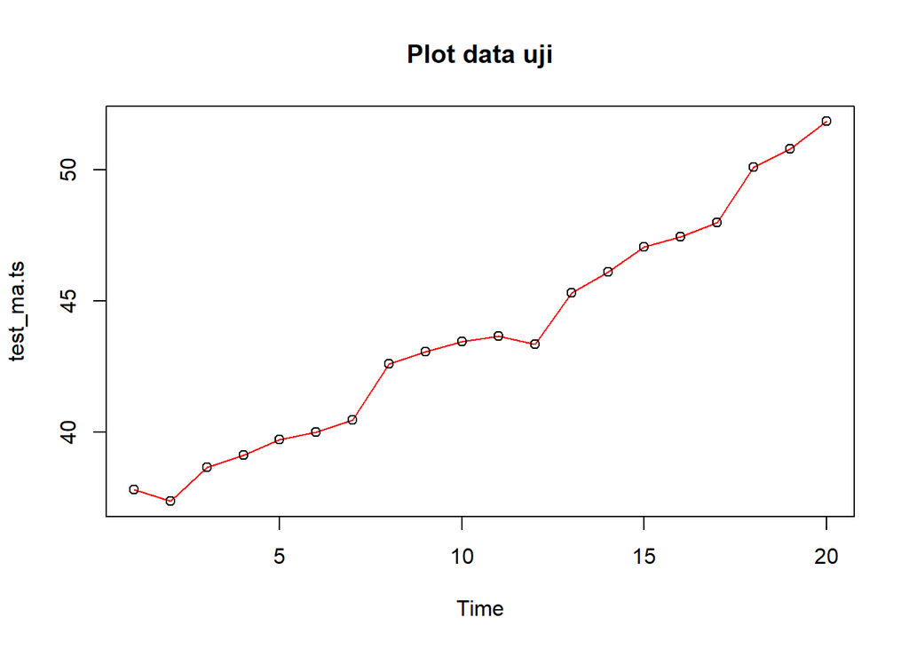

```r
#eksplorasi data uji
plot(test_ma.ts, col="red",main="Plot data uji")
points(test_ma.ts)
```

Eksplorasi menggunakan package ggplot2

```r
library(ggplot2)
```

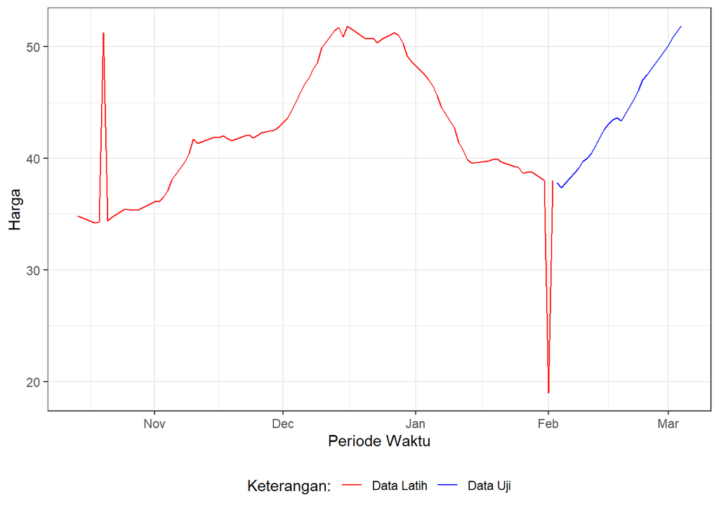

```r
ggplot() +
  geom_line(data = training_ma, aes(x = Tanggal, y = Harga, col = "Data Latih")) +
  geom_line(data = testing_ma, aes(x = Tanggal, y = Harga, col = "Data Uji")) +
  labs(x = "Periode Waktu", y = "Harga", color = "Legend") +
   scale_colour_manual(name="Keterangan:", breaks = c("Data Latih", "Data Uji"),
                      values = c("red", "blue")) +
  theme_bw() + theme(legend.position = "bottom",
                     plot.caption = element_text(hjust=0.5, size=12))
```

## Single Moving Average (SMA)

uji N terbaik

```r
N <- 2:8

hasil_sma <- data.frame(
  N = N,
  SSE = NA,
  MSE = NA,
  RMSE = NA,
  MAPE = NA
)

for (i in 1:length(N)) {

  n_sma <- N[i]

  # SMA data training
  sma <- SMA(train_ma.ts, n = n_sma)

  # Nilai terakhir SMA digunakan untuk meramal data testing
  ramalan <- rep(
    tail(na.omit(sma), 1),
    length(test_ma.ts)
  )

  # Error
  error <- test_ma.ts - ramalan

  # Akurasi
  hasil_sma$SSE[i] <- sum(error^2)
  hasil_sma$MSE[i] <- mean(error^2)
  hasil_sma$RMSE[i] <- sqrt(mean(error^2))
  hasil_sma$MAPE[i] <- mean(
    abs(error / test_ma.ts) * 100
  )
}

hasil_sma
```

```
##   N      SSE       MSE      RMSE     MAPE
## 1 2 5049.275 252.46375 15.889108 34.28692
## 2 3 3305.021 165.25103 12.855000 26.94704
## 3 4 2506.738 125.33691 11.195397 22.84477
## 4 5 2092.251 104.61255 10.228028 20.40647
## 5 6 1846.493  92.32465  9.608572 18.81936
## 6 7 1657.253  82.86264  9.102892 17.50455
## 7 8 1520.070  76.00348  8.717997 16.48962
```

```r
data.sma<-SMA(train_ma.ts, n=8)
data.sma
```

```
## Time Series:
## Start = 1
## End = 80
## Frequency = 1
##  [1]       NA       NA       NA       NA       NA       NA       NA 36.73750
##  [9] 36.80625 36.88750 37.03125 37.18750 35.29375 35.50625 35.72500 35.93125
## [17] 36.26875 36.80625 37.44375 38.21250 38.86875 39.54375 40.21875 40.81250
## [25] 41.30000 41.56250 41.70625 41.74375 41.83750 41.87500 41.89375 41.95000
## [33] 42.01875 42.15000 42.35000 42.55000 42.82500 43.43125 44.07500 44.78750
## [41] 45.53750 46.42500 47.45625 48.47500 49.29375 49.93750 50.48750 50.83125
## [49] 51.10000 51.20625 51.06875 50.93125 50.98125 50.88125 50.71875 50.51875
## [57] 50.26250 49.85625 49.44375 48.91875 48.21250 47.40625 46.46250 45.50000
## [65] 44.51250 43.56250 42.62500 41.78125 41.05000 40.46875 40.11875 39.89375
## [73] 39.71250 39.62500 39.51250 39.39375 39.27500 39.04375 36.42500 36.21875
```

Data pemulusan pada periode ke-t selanjutnya digunakan sebagai nilai peramalan pada periode ke t+1 sehingga hasil peramalan 1 periode kedepan adalah sebagai berikut.

```r
data.ramal<-c(NA,data.sma)
data.ramal #forecast 1 periode ke depan
```

```
##  [1]       NA       NA       NA       NA       NA       NA       NA       NA
##  [9] 36.73750 36.80625 36.88750 37.03125 37.18750 35.29375 35.50625 35.72500
## [17] 35.93125 36.26875 36.80625 37.44375 38.21250 38.86875 39.54375 40.21875
## [25] 40.81250 41.30000 41.56250 41.70625 41.74375 41.83750 41.87500 41.89375
## [33] 41.95000 42.01875 42.15000 42.35000 42.55000 42.82500 43.43125 44.07500
## [41] 44.78750 45.53750 46.42500 47.45625 48.47500 49.29375 49.93750 50.48750
## [49] 50.83125 51.10000 51.20625 51.06875 50.93125 50.98125 50.88125 50.71875
## [57] 50.51875 50.26250 49.85625 49.44375 48.91875 48.21250 47.40625 46.46250
## [65] 45.50000 44.51250 43.56250 42.62500 41.78125 41.05000 40.46875 40.11875
## [73] 39.89375 39.71250 39.62500 39.51250 39.39375 39.27500 39.04375 36.42500
## [81] 36.21875
```

Selanjutnya dilakukan peramalan sebanyak 20 periode sesuai dengan jumlah data uji yang digunakan. Pada metode SMA, seluruh hasil peramalan untuk 20 periode ke depan memiliki nilai yang sama dengan hasil ramalan satu periode ke depan karena nilai ramalan ditentukan berdasarkan nilai pemulusan terakhir.

```r
data.gab<-cbind(
  aktual=c(data2.ts),
  pemulusan=c(data.sma,rep(NA,20)),
  ramalan=c(data.ramal,rep(data.ramal[length(data.ramal)],19)))

data.gab #forecast 24 periode ke depan
```

```
##        aktual pemulusan  ramalan
##   [1,]  34.85        NA       NA
##   [2,]  34.70        NA       NA
##   [3,]  34.20        NA       NA
##   [4,]  34.30        NA       NA
##   [5,]  51.25        NA       NA
##   [6,]  34.40        NA       NA
##   [7,]  34.75        NA       NA
##   [8,]  35.45  36.73750       NA
##   [9,]  35.40  36.80625 36.73750
##  [10,]  35.35  36.88750 36.80625
##  [11,]  35.35  37.03125 36.88750
##  [12,]  35.55  37.18750 37.03125
##  [13,]  36.10  35.29375 37.18750
##  [14,]  36.10  35.50625 35.29375
```

[output cut: 86 more lines]

Adapun plot data deret waktu dari hasil peramalan yang dilakukan adalah sebagai berikut.

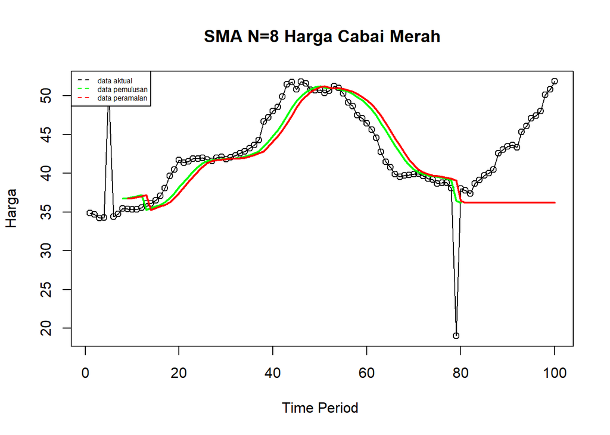

```r
ts.plot(data2.ts, xlab="Time Period ", ylab="Harga", main= "SMA N=8 Harga Cabai Merah")
points(data2.ts)
lines(data.gab[,2],col="green",lwd=2)
lines(data.gab[,3],col="red",lwd=2)
legend("topleft",c("data aktual","data pemulusan","data peramalan"), lty=8, col=c("black","green","red"), cex=0.5)
```

```r
#Menghitung nilai keakuratan data latih
error_train.sma = train_ma.ts-data.ramal[1:length(train_ma.ts)]

SSE_train.sma = sum(error_train.sma[9:length(train_ma.ts)]^2)
MSE_train.sma = mean(error_train.sma[9:length(train_ma.ts)]^2)
MAPE_train.sma = mean(abs((error_train.sma[9:length(train_ma.ts)]/train_ma.ts[9:length(train_ma.ts)])*100))

akurasi_train.sma <- matrix(c(SSE_train.sma, MSE_train.sma, MAPE_train.sma))
row.names(akurasi_train.sma)<- c("SSE", "MSE", "MAPE")
colnames(akurasi_train.sma) <- c("Akurasi m = 8")
akurasi_train.sma
```

```
##      Akurasi m = 8
## SSE     816.086719
## MSE      11.334538
## MAPE      5.813332
```

Dalam hal ini nilai MAPE data latih pada metode pemulusan SMA sekitar 5.8%, nilai ini dapat dikategorikan sebagai nilai akurasi yang sangat baik. Selanjutnya dilakukan perhitungan nilai MAPE data uji pada metode pemulusan SMA.

```r
#Menghitung nilai keakuratan data uji
error_test.sma = test_ma.ts-data.gab[81:100,3]

SSE_test.sma = sum(error_test.sma^2)
MSE_test.sma = mean(error_test.sma^2)
MAPE_test.sma = mean(abs((error_test.sma/test_ma.ts*100)))

akurasi_test.sma <- matrix(c(SSE_test.sma, MSE_test.sma, MAPE_test.sma))
row.names(akurasi_test.sma)<- c("SSE", "MSE", "MAPE")
colnames(akurasi_test.sma) <- c("Akurasi m = 8")
akurasi_test.sma
```

```
##      Akurasi m = 8
## SSE     1520.06953
## MSE       76.00348
## MAPE      16.48962
```

Berdasarkan hasil perhitungan akurasi pada data uji, metode SMA dengan N=8 menghasilkan nilai MAPE sebesar 16,4896%. Berdasarkan nilai tersebut, hasil peramalan dapat dikategorikan baik.

## Double Moving Average (DMA)

mencari N terbaik

```r
N <- 2:8

hasil_dma <- data.frame(
  N = N,
  SSE = NA,
  MSE = NA,
  RMSE = NA,
  MAPE = NA
)

for (i in 1:length(N)) {

  n_dma <- N[i]

  # Pemulusan pertama
  dma1 <- SMA(train_ma.ts, n = n_dma)

  # Pemulusan kedua
  dma2 <- SMA(dma1, n = n_dma)

  # Nilai At
  At <- 2 * dma1 - dma2

  # Nilai Bt
  Bt <- 2 / (n_dma - 1) * (dma1 - dma2)

  # Peramalan data testing
  ramalan <- c()

  for (j in 1:length(test_ma.ts)) {

    ramalan[j] <-
      At[length(At)] +
      Bt[length(Bt)] * j

  }

  # Error
  error <- test_ma.ts - ramalan

  # Akurasi
  hasil_dma$SSE[i] <- sum(error^2)
  hasil_dma$MSE[i] <- mean(error^2)
  hasil_dma$RMSE[i] <- sqrt(mean(error^2))
  hasil_dma$MAPE[i] <- mean(
    abs(error / test_ma.ts) * 100
  )
}

hasil_dma
```

```
##   N       SSE       MSE     RMSE     MAPE
## 1 2  5244.041  262.2020 16.19265 34.88881
## 2 3 37481.679 1874.0839 43.29069 86.79526
## 3 4 24301.967 1215.0984 34.85826 69.78207
## 4 5 16287.885  814.3943 28.53759 57.05486
## 5 6 12174.516  608.7258 24.67237 49.24388
## 6 7  9290.788  464.5394 21.55318 42.87888
## 7 8  7365.117  368.2558 19.18999 38.02565
```

```r
dma <- SMA(data.sma, n = 8)
At <- 2*data.sma - dma
Bt <- 2/(8-1)*(data.sma - dma)
data.dma<- At+Bt
data.ramal2<- c(NA, data.dma)

t = 1:20
f = c()

for (i in t) {
  f[i] = At[length(At)] + Bt[length(Bt)]*(i)
}

data.gab2 <- cbind(aktual = c(data2.ts),
                   pemulusan1 = c(data.sma,rep(NA,20)),
                   pemulusan2 = c(dma, rep(NA,20)),
                   At = c(At, rep(NA,20)),
                   Bt = c(Bt,rep(NA,20)),
                   ramalan = c(data.ramal2, f[-1]))
data.gab2
```

```
##        aktual pemulusan1 pemulusan2       At          Bt  ramalan
##   [1,]  34.85         NA         NA       NA          NA       NA
##   [2,]  34.70         NA         NA       NA          NA       NA
##   [3,]  34.20         NA         NA       NA          NA       NA
##   [4,]  34.30         NA         NA       NA          NA       NA
##   [5,]  51.25         NA         NA       NA          NA       NA
##   [6,]  34.40         NA         NA       NA          NA       NA
##   [7,]  34.75         NA         NA       NA          NA       NA
##   [8,]  35.45   36.73750         NA       NA          NA       NA
##   [9,]  35.40   36.80625         NA       NA          NA       NA
##  [10,]  35.35   36.88750         NA       NA          NA       NA
##  [11,]  35.35   37.03125         NA       NA          NA       NA
##  [12,]  35.55   37.18750         NA       NA          NA       NA
##  [13,]  36.10   35.29375         NA       NA          NA       NA
##  [14,]  36.10   35.50625         NA       NA          NA       NA
```

[output cut: 86 more lines]

Hasil pemulusan menggunakan metode DMA divisualisasikan sebagai berikut

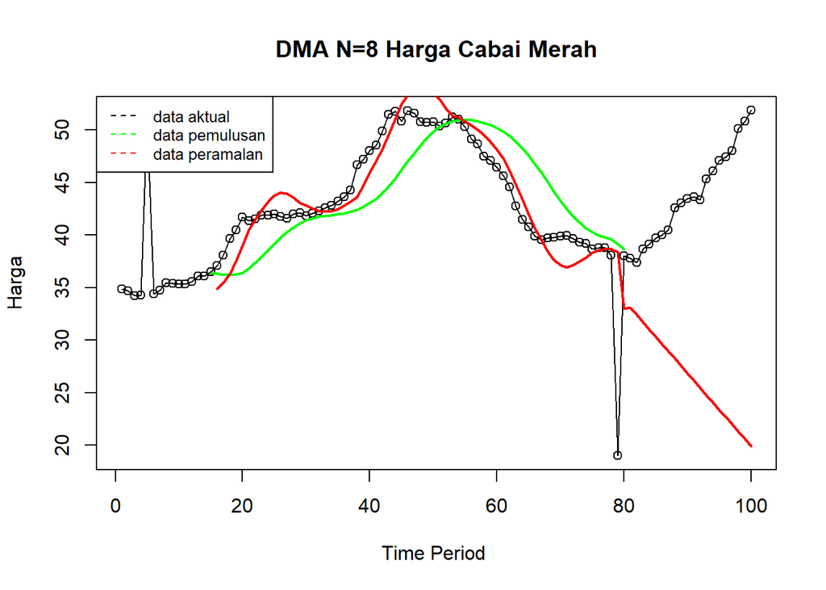

```r
ts.plot(data2.ts, xlab="Time Period ", ylab="Harga", main= "DMA N=8 Harga Cabai Merah")
points(data2.ts)
lines(data.gab2[,3],col="green",lwd=2)
lines(data.gab2[,6],col="red",lwd=2)
legend("topleft",c("data aktual","data pemulusan","data peramalan"), lty=8, col=c("black","green","red"), cex=0.8)
```

Selanjutnya perhitungan akurasi dilakukan baik pada data latih maupun data uji. Perhitungan akurasi dilakukan dengan ukuran akurasi SSE, MSE dan MAPE.

```r
error_train.dma = train_ma.ts-data.ramal2[1:length(train_ma.ts)]

SSE_train.dma = sum(error_train.dma[16:length(train_ma.ts)]^2)
MSE_train.dma = mean(error_train.dma[16:length(train_ma.ts)]^2)
MAPE_train.dma = mean(abs((error_train.dma[16:length(train_ma.ts)]/train_ma.ts[16:length(train_ma.ts)])*100))

akurasi_train.dma <- matrix(c(SSE_train.dma, MSE_train.dma, MAPE_train.dma))
row.names(akurasi_train.dma)<- c("SSE", "MSE", "MAPE")
colnames(akurasi_train.dma) <- c("Akurasi m = 8")
akurasi_train.dma
```

```
##      Akurasi m = 8
## SSE     600.906250
## MSE       9.244712
## MAPE      5.136097
```

Berdasarkan hasil perhitungan akurasi pada data latih, metode DMA dengan N=8 menghasilkan nilai MAPE sebesar 5,1361%. Nilai MAPE yang kurang dari 10% menunjukkan bahwa hasil pemulusan pada data latih dapat dikategorikan sangat baik.

```r
#Menghitung nilai keakuratan data uji
error_test.dma = test_ma.ts-data.gab2[81:100,6]
SSE_test.dma = sum(error_test.dma^2)
MSE_test.dma = mean(error_test.dma^2)
MAPE_test.dma = mean(abs((error_test.dma/test_ma.ts*100)))

akurasi_test.dma <- matrix(c(SSE_test.dma, MSE_test.dma, MAPE_test.dma))
row.names(akurasi_test.dma)<- c("SSE", "MSE", "MAPE")
colnames(akurasi_test.dma) <- c("Akurasi m = 8")
akurasi_test.dma
```

```
##      Akurasi m = 8
## SSE     7365.11681
## MSE      368.25584
## MAPE      38.02565
```

Berdasarkan hasil evaluasi pada data uji, metode SMA dengan N=8 memberikan kinerja peramalan yang baik. Hal ini ditunjukkan oleh nilai MSE dan MAPE metode SMA yang lebih kecil, yaitu masing-masing sebesar 76.0035 dan 16.4896%, dibandingkan metode DMA yang menghasilkan MSE sebesar 368.2558 dan MAPE sebesar 38.0257%. Dengan demikian, berdasarkan hasil pengujian pada data uji, metode SMA lebih baik dalam melakukan peramalan harga cabai merah dibandingkan metode DMA.

# Single Exponential Smoothing & Double Exponential Smoothing

## Pembagian data

Pembagian data latih dan data uji dilakukan dengan perbandingan 80% data latih dan 20% data uji.

```r
# jumlah baris data
n <- nrow(data2)

# hitung batas 80%
n_train <- floor(0.8 * n)

# bagi data
training <- data2[1:n_train, ]
testing  <- data2[(n_train+1):n, ]

# ubah ke time series
train.ts <- ts(training$Harga)
test.ts  <- ts(testing$Harga)
```

## Eksplorasi

Eksplorasi dilakukan dengan membuat plot data deret waktu untuk keseluruhan data, data latih, dan data uji.

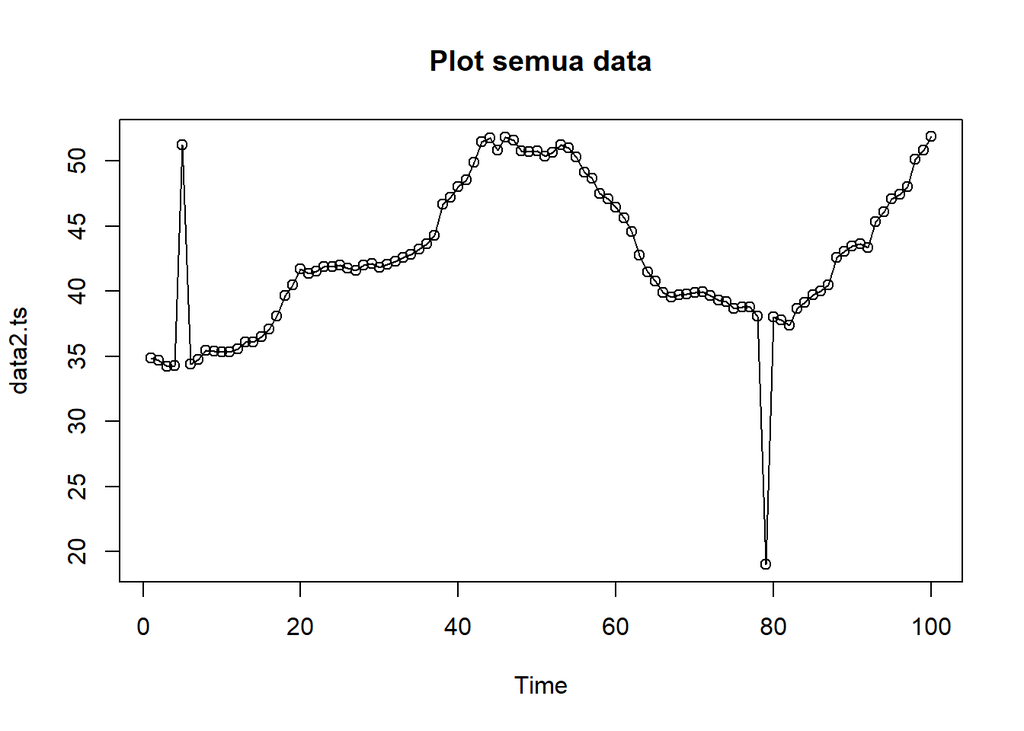

```r
plot(data2.ts, col="black",main="Plot semua data")
points(data2.ts)
```

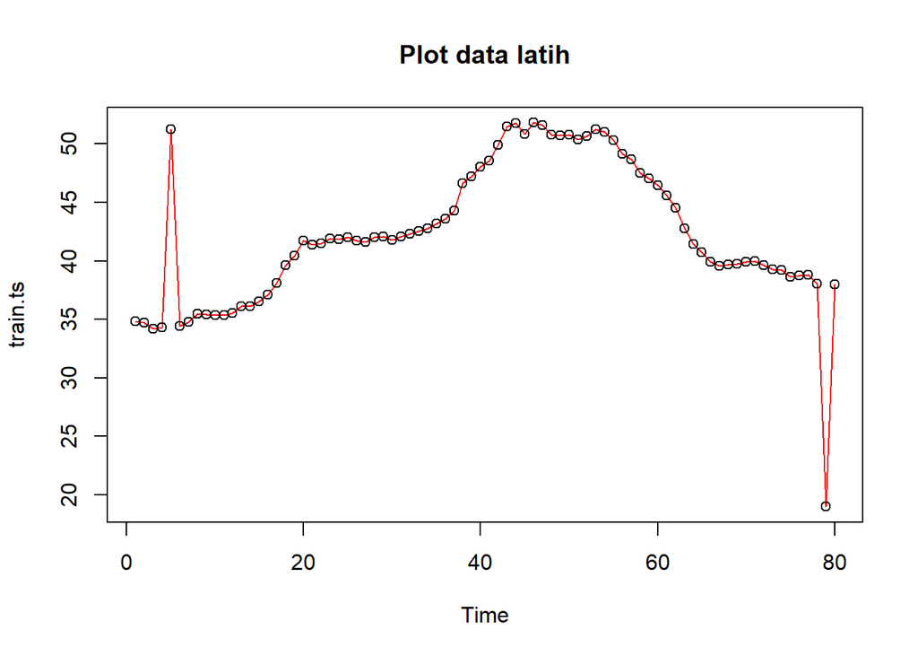

```r
plot(train.ts, col="red",main="Plot data latih")
points(train.ts)
```

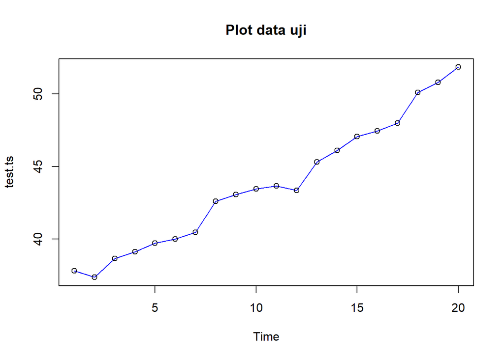

```r
plot(test.ts, col="blue",main="Plot data uji")
points(test.ts)
```

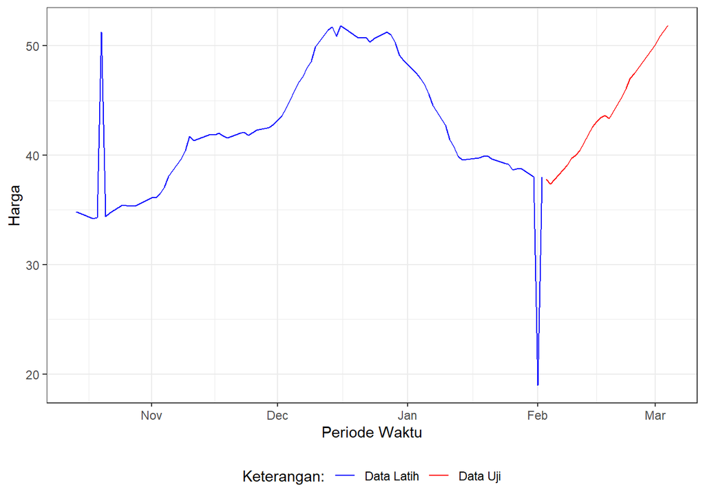

```r
#Eksplorasi dengan GGPLOT
library(ggplot2)
ggplot() +
  geom_line(data = training, aes(x = Tanggal, y = Harga, col = "Data Latih")) +
  geom_line(data = testing, aes(x = Tanggal, y = Harga, col = "Data Uji")) +
  labs(x = "Periode Waktu", y = "Harga", color = "Legend") +
  scale_colour_manual(name="Keterangan:", breaks = c("Data Latih", "Data Uji"),
                      values = c("blue", "red")) +
  theme_bw() + theme(legend.position = "bottom",
                     plot.caption = element_text(hjust=0.5, size=12))
```

## Single Exponential Smoothing (SES)

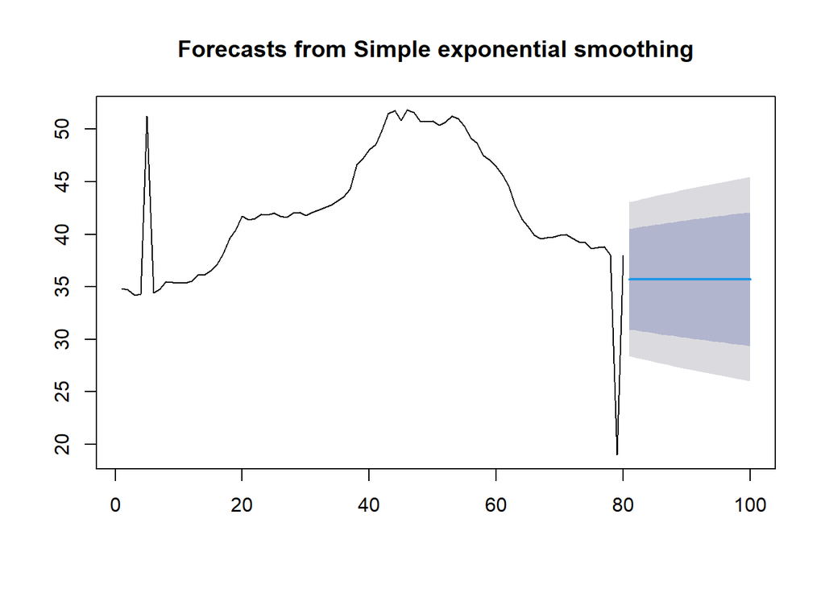

```r
#Cara 1 (fungsi ses)
ses.1 <- ses(train.ts, h = 20, alpha = 0.2)
plot(ses.1)
```

```r
ses.1
```

```
##     Point Forecast    Lo 80    Hi 80    Lo 95    Hi 95
##  81       35.73198 30.93889 40.52507 28.40158 43.06238
##  82       35.73198 30.84397 40.61999 28.25641 43.20755
##  83       35.73198 30.75085 40.71311 28.11401 43.34995
##  84       35.73198 30.65945 40.80451 27.97421 43.48974
##  85       35.73198 30.56966 40.89430 27.83690 43.62706
##  86       35.73198 30.48141 40.98255 27.70193 43.76203
##  87       35.73198 30.39462 41.06934 27.56919 43.89477
##  88       35.73198 30.30922 41.15474 27.43858 44.02538
##  89       35.73198 30.22514 41.23882 27.30999 44.15397
##  90       35.73198 30.14232 41.32164 27.18334 44.28062
##  91       35.73198 30.06072 41.40324 27.05853 44.40542
##  92       35.73198 29.98027 41.48369 26.93550 44.52846
##  93       35.73198 29.90093 41.56303 26.81416 44.64979
##  94       35.73198 29.82266 41.64130 26.69446 44.76950
##  95       35.73198 29.74541 41.71855 26.57631 44.88765
##  96       35.73198 29.66915 41.79481 26.45968 45.00428
##  97       35.73198 29.59383 41.87013 26.34449 45.11947
##  98       35.73198 29.51942 41.94453 26.23070 45.23326
##  99       35.73198 29.44590 42.01806 26.11825 45.34571
## 100       35.73198 29.37323 42.09073 26.00711 45.45685
```

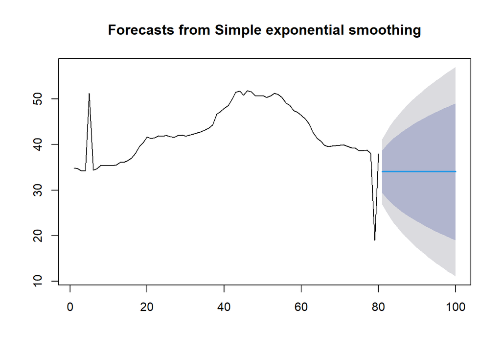

```r
ses.2<- ses(train.ts, h = 20, alpha = 0.7)
plot(ses.2)
```

```r
ses.2
```

```
##     Point Forecast    Lo 80    Hi 80    Lo 95    Hi 95
##  81       34.03455 29.35564 38.71346 26.87878 41.19033
##  82       34.03455 28.32322 39.74589 25.29982 42.76929
##  83       34.03455 27.45074 40.61836 23.96549 44.10362
##  84       34.03455 26.68107 41.38804 22.78837 45.28074
##  85       34.03455 25.98465 42.08445 21.72329 46.34581
##  86       34.03455 25.34386 42.72524 20.74329 47.32581
##  87       34.03455 24.74718 43.32192 19.83075 48.23836
##  88       34.03455 24.18659 43.88252 18.97339 49.09572
##  89       34.03455 23.65623 44.41288 18.16228 49.90683
##  90       34.03455 23.15169 44.91742 17.39065 50.67846
##  91       34.03455 22.66952 45.39958 16.65324 51.41587
##  92       34.03455 22.20700 45.86211 15.94586 52.12324
##  93       34.03455 21.76189 46.30722 15.26513 52.80397
##  94       34.03455 21.33237 46.73674 14.60824 53.46087
##  95       34.03455 20.91691 47.15220 13.97284 54.09626
##  96       34.03455 20.51420 47.55490 13.35696 54.71214
##  97       34.03455 20.12315 47.94595 12.75891 55.31020
##  98       34.03455 19.74280 48.32631 12.17720 55.89190
##  99       34.03455 19.37231 48.69680 11.61059 56.45852
## 100       34.03455 19.01095 49.05815 11.05794 57.01116
```

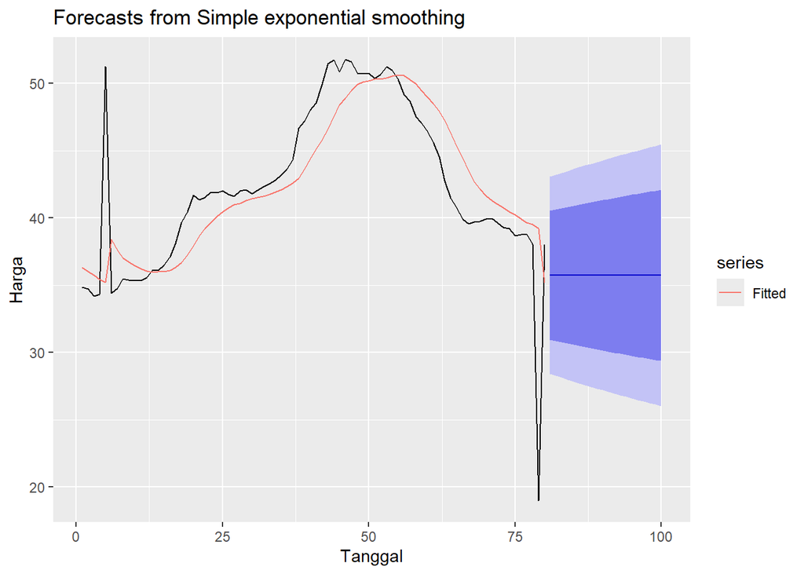

```r
autoplot(ses.1) +
  autolayer(fitted(ses.1), series="Fitted") +
  ylab("Harga") + xlab("Tanggal")
```

Selanjutnya akan digunakan fungsi HoltWinters() dengan nilai inisialisasi parameter dan panjang periode peramalan yang sama dengan fungsi ses() .

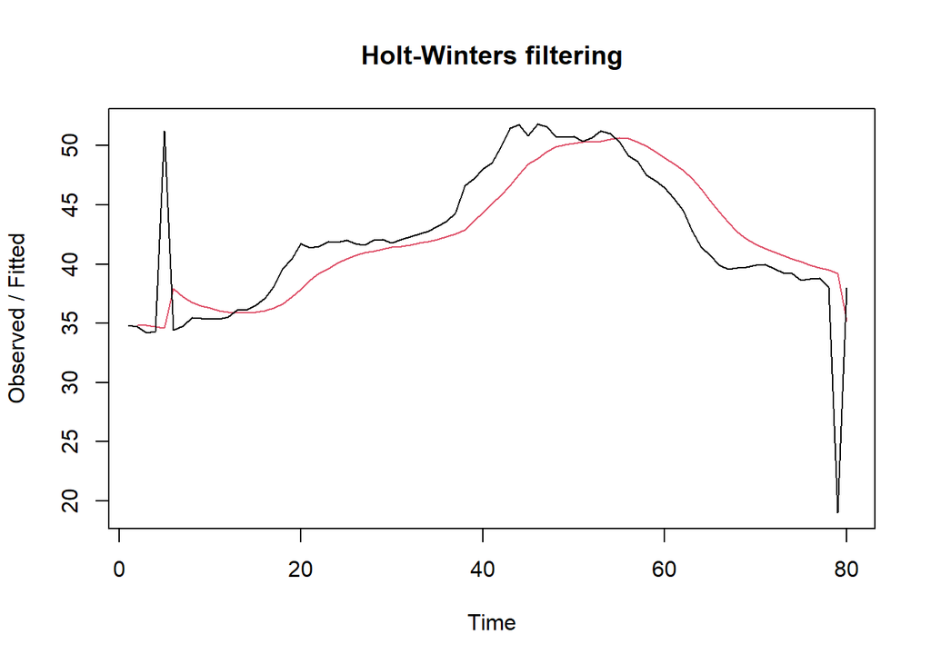

```r
#Cara 2 (fungsi Holtwinter)
ses1<- HoltWinters(train.ts, gamma = FALSE, beta = FALSE, alpha = 0.2)
plot(ses1)
```

```r
ramalan1<- forecast(ses1, h=20)
ramalan1
```

```
##     Point Forecast    Lo 80    Hi 80    Lo 95    Hi 95
##  81       35.73198 30.92666 40.53730 28.38287 43.08109
##  82       35.73198 30.83149 40.63247 28.23733 43.22663
##  83       35.73198 30.73814 40.72582 28.09456 43.36940
##  84       35.73198 30.64650 40.81746 27.95441 43.50954
##  85       35.73198 30.55649 40.90747 27.81675 43.64721
##  86       35.73198 30.46801 40.99595 27.68144 43.78252
##  87       35.73198 30.38100 41.08296 27.54836 43.91560
##  88       35.73198 30.29538 41.16858 27.41741 44.04655
##  89       35.73198 30.21108 41.25288 27.28850 44.17546
##  90       35.73198 30.12806 41.33590 27.16152 44.30244
##  91       35.73198 30.04624 41.41771 27.03640 44.42756
##  92       35.73198 29.96559 41.49837 26.91305 44.55091
##  93       35.73198 29.88605 41.57791 26.79140 44.67255
##  94       35.73198 29.80758 41.65638 26.67139 44.79257
##  95       35.73198 29.73013 41.73383 26.55295 44.91101
##  96       35.73198 29.65367 41.81029 26.43601 45.02795
##  97       35.73198 29.57816 41.88580 26.32053 45.14343
##  98       35.73198 29.50357 41.96039 26.20645 45.25751
##  99       35.73198 29.42986 42.03410 26.09372 45.37024
## 100       35.73198 29.35700 42.10696 25.98229 45.48167
```

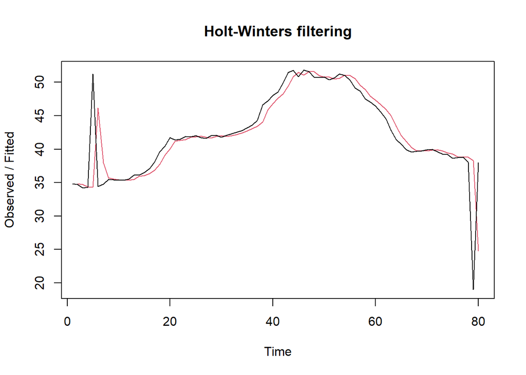

```r
ses2<- HoltWinters(train.ts, gamma = FALSE, beta = FALSE, alpha = 0.7)
plot(ses2)
```

```r
ramalan2<- forecast(ses2, h=20)
ramalan2
```

```
##     Point Forecast    Lo 80    Hi 80    Lo 95    Hi 95
##  81       34.03455 29.35568 38.71342 26.87884 41.19027
##  82       34.03455 28.32326 39.74584 25.29989 42.76922
##  83       34.03455 27.45080 40.61831 23.96557 44.10354
##  84       34.03455 26.68113 41.38798 22.78846 45.28064
##  85       34.03455 25.98472 42.08439 21.72339 46.34571
##  86       34.03455 25.34394 42.72517 20.74340 47.32571
##  87       34.03455 24.74726 43.32185 19.83086 48.23824
##  88       34.03455 24.18667 43.88244 18.97351 49.09559
##  89       34.03455 23.65631 44.41279 18.16241 49.90670
##  90       34.03455 23.15178 44.91733 17.39078 50.67832
##  91       34.03455 22.66961 45.39949 16.65338 51.41573
##  92       34.03455 22.20709 45.86201 15.94601 52.12309
##  93       34.03455 21.76199 46.30712 15.26529 52.80382
##  94       34.03455 21.33247 46.73663 14.60840 53.46071
##  95       34.03455 20.91701 47.15209 13.97301 54.09610
##  96       34.03455 20.51432 47.55479 13.35713 54.71197
##  97       34.03455 20.12327 47.94584 12.75908 55.31003
##  98       34.03455 19.74292 48.32619 12.17738 55.89172
##  99       34.03455 19.37243 48.69667 11.61077 56.45833
## 100       34.03455 19.01108 49.05803 11.05813 57.01098
```

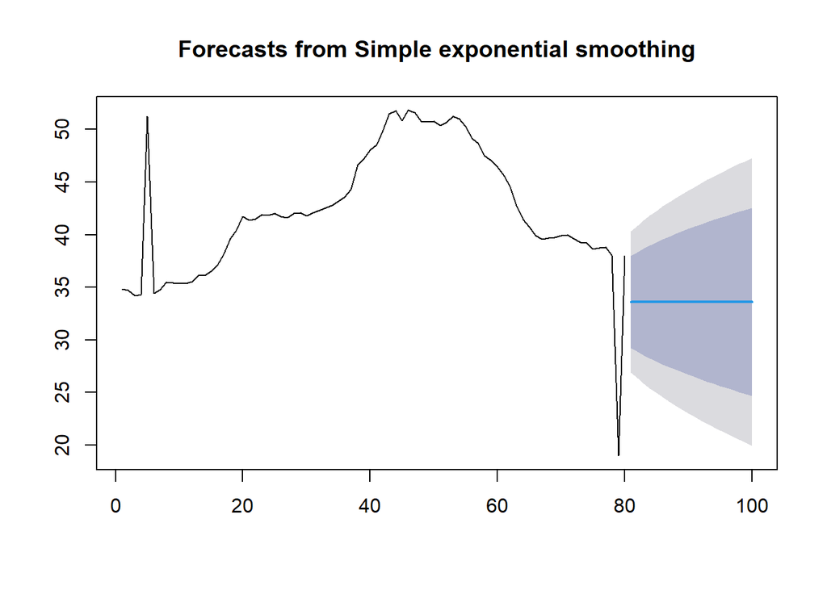

```r
#SES
ses.opt <- ses(train.ts, h = 20, alpha = NULL)
plot(ses.opt)
```

```r
ses.opt
```

```
##     Point Forecast    Lo 80    Hi 80    Lo 95    Hi 95
##  81       33.61459 29.22018 38.00900 26.89392 40.33525
##  82       33.61459 28.87194 38.35723 26.36134 40.86784
##  83       33.61459 28.54758 38.68160 25.86527 41.36391
##  84       33.61459 28.24277 38.98641 25.39910 41.83008
##  85       33.61459 27.95435 39.27483 24.95800 42.27118
##  86       33.61459 27.67993 39.54925 24.53831 42.69087
##  87       33.61459 27.41765 39.81153 24.13719 43.09199
##  88       33.61459 27.16603 40.06315 23.75237 43.47681
##  89       33.61459 26.92386 40.30532 23.38201 43.84717
##  90       33.61459 26.69016 40.53902 23.02459 44.20459
##  91       33.61459 26.46409 40.76508 22.67885 44.55033
##  92       33.61459 26.24496 40.98422 22.34371 44.88547
##  93       33.61459 26.03215 41.19702 22.01825 45.21092
##  94       33.61459 25.82516 41.40402 21.70169 45.52749
##  95       33.61459 25.62353 41.60565 21.39331 45.83586
##  96       33.61459 25.42686 41.80232 21.09253 46.13664
##  97       33.61459 25.23480 41.99438 20.79881 46.43037
##  98       33.61459 25.04705 42.18213 20.51167 46.71751
##  99       33.61459 24.86333 42.36585 20.23069 46.99849
## 100       33.61459 24.68338 42.54580 19.95549 47.27369
```

```r
#Lamda Optimum Holt Winter
HWopt<- HoltWinters(train.ts, gamma = FALSE, beta = FALSE,alpha = NULL)
HWopt
```

```
## Holt-Winters exponential smoothing without trend and without seasonal component.
##
## Call:
## HoltWinters(x = train.ts, alpha = NULL, beta = FALSE, gamma = FALSE)
##
## Smoothing parameters:
##  alpha: 0.4078817
##  beta : FALSE
##  gamma: FALSE
##
## Coefficients:
##      [,1]
## a 33.6054
```

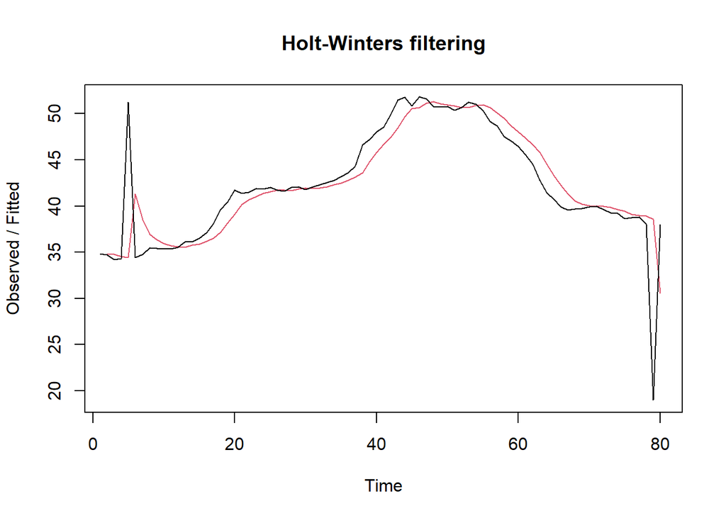

```r
plot(HWopt)
```

```r
#ramalan
ramalanopt<- forecast(HWopt, h=20)
ramalanopt
```

```
##     Point Forecast    Lo 80    Hi 80    Lo 95    Hi 95
##  81        33.6054 29.20971 38.00110 26.88277 40.32804
##  82        33.6054 28.85812 38.35269 26.34506 40.86575
##  83        33.6054 28.53083 38.67998 25.84452 41.36629
##  84        33.6054 28.22341 38.98740 25.37436 41.83645
##  85        33.6054 27.93263 39.27818 24.92964 42.28117
##  86        33.6054 27.65604 39.55477 24.50663 42.70418
##  87        33.6054 27.39174 39.81906 24.10243 43.10838
##  88        33.6054 27.13825 40.07256 23.71474 43.49607
##  89        33.6054 26.89432 40.31649 23.34168 43.86913
##  90        33.6054 26.65895 40.55186 22.98171 44.22910
##  91        33.6054 26.43129 40.77951 22.63355 44.57726
##  92        33.6054 26.21065 41.00016 22.29610 44.91471
##  93        33.6054 25.99640 41.21441 21.96843 45.24238
##  94        33.6054 25.78802 41.42279 21.64974 45.56107
##  95        33.6054 25.58505 41.62576 21.33932 45.87148
##  96        33.6054 25.38709 41.82372 21.03657 46.17423
##  97        33.6054 25.19379 42.01702 20.74095 46.46986
##  98        33.6054 25.00483 42.20598 20.45196 46.75885
##  99        33.6054 24.81994 42.39087 20.16919 47.04162
## 100        33.6054 24.63885 42.57195 19.89225 47.31856
```

```r
#Keakuratan Metode
#Pada data training

# SES dengan alpha = 0.2
SSE1<-ses1$SSE
MSE1<-ses1$SSE/length(train.ts)
RMSE1<-sqrt(MSE1)

akurasi1 <- matrix(c(SSE1,MSE1,RMSE1))
row.names(akurasi1)<- c("SSE", "MSE", "RMSE")
colnames(akurasi1) <- c("Akurasi lamda=0.2")
akurasi1
```

```
##      Akurasi lamda=0.2
## SSE        1096.895179
## MSE          13.711190
## RMSE          3.702862
```

```r
# SES dengan alpha = 0.7
SSE2<-ses2$SSE
MSE2<-ses2$SSE/length(train.ts)
RMSE2<-sqrt(MSE2)

akurasi2 <- matrix(c(SSE2,MSE2,RMSE2))
row.names(akurasi2)<- c("SSE", "MSE", "RMSE")
colnames(akurasi2) <- c("Akurasi lamda=0.7")
akurasi2
```

```
##      Akurasi lamda=0.7
## SSE        1039.708913
## MSE          12.996361
## RMSE          3.605047
```

```r
SSE1<-ses1$SSE
SSE1
```

```
## [1] 1096.895
```

```r
#Cara Manual
# Alpha = 0.2
fitted1<-ramalan1$fitted
sisaan1<-ramalan1$residuals
head(sisaan1)
```

```
## Time Series:
## Start = 1
## End = 6
## Frequency = 1
## [1]       NA -0.15000 -0.62000 -0.39600 16.63320 -3.54344
```

```r
resid1<-training$Harga-ramalan1$fitted
head(resid1)
```

```
## Time Series:
## Start = 1
## End = 6
## Frequency = 1
## [1]       NA -0.15000 -0.62000 -0.39600 16.63320 -3.54344
```

```r
SSE.1=sum(sisaan1[2:length(train.ts)]^2)
SSE.1
```

```
## [1] 1096.895
```

```r
MSE.1 = SSE.1/length(train.ts)
MSE.1
```

```
## [1] 13.71119
```

```r
MAPE.1 = sum(abs(sisaan1[2:length(train.ts)]/train.ts[2:length(train.ts)])*
               100)/length(train.ts)
MAPE.1
```

```
## [1] 5.992102
```

```r
akurasi.1 <- matrix(c(SSE.1,MSE.1,MAPE.1))
row.names(akurasi.1)<- c("SSE", "MSE", "MAPE")
colnames(akurasi.1) <- c("Akurasi lamda=0.2")
akurasi.1
```

```
##      Akurasi lamda=0.2
## SSE        1096.895179
## MSE          13.711190
## MAPE          5.992102
```

```r
# Alpha = 0.7
fitted2<-ramalan2$fitted
sisaan2<-ramalan2$residuals
head(sisaan2)
```

```
## Time Series:
## Start = 1
## End = 6
## Frequency = 1
## [1]        NA  -0.15000  -0.54500  -0.06350  16.93095 -11.77072
```

```r
resid2<-training$Harga-ramalan2$fitted
head(resid2)
```

```
## Time Series:
## Start = 1
## End = 6
## Frequency = 1
## [1]        NA  -0.15000  -0.54500  -0.06350  16.93095 -11.77072
```

```r
SSE.2=sum(sisaan2[2:length(train.ts)]^2)
SSE.2
```

```
## [1] 1039.709
```

```r
MSE.2 = SSE.2/length(train.ts)
MSE.2
```

```
## [1] 12.99636
```

```r
MAPE.2 = sum(abs(sisaan2[2:length(train.ts)]/train.ts[2:length(train.ts)])*
               100)/length(train.ts)
MAPE.2
```

```
## [1] 4.037211
```

```r
akurasi.2 <- matrix(c(SSE.2,MSE.2,MAPE.2))
row.names(akurasi.2)<- c("SSE", "MSE", "MAPE")
colnames(akurasi.2) <- c("Akurasi lamda=0.7")
akurasi.2
```

```
##      Akurasi lamda=0.7
## SSE        1039.708913
## MSE          12.996361
## MAPE          4.037211
```

Berdasarkan hasil evaluasi pada data latih, kinerja SES dengan α = 0,2 dan α = 0,7 dibandingkan menggunakan nilai SSE, MSE, RMSE, dan MAPE. Parameter yang menghasilkan nilai metrik kesalahan lebih kecil menunjukkan kinerja pemulusan yang lebih baik. Nilai MAPE tersebut menunjukkan bahwa hasil peramalan dapat dikategorikan sangat baik.

```r
#akurasi data uji
n_test <- nrow(testing)

# error (ramalan - aktual), samakan panjang dan tipe numeric
e1   <- as.numeric(ramalan1$mean)[1:n_test] - as.numeric(testing$Harga)
e2   <- as.numeric(ramalan2$mean)[1:n_test] - as.numeric(testing$Harga)
eopt <- as.numeric(ramalanopt$mean)[1:n_test] - as.numeric(testing$Harga)

# SSE / MSE / RMSE untuk masing-masing model (abaikan NA)
SSEtesting1  <- sum(e1^2,  na.rm = TRUE)
MSEtesting1  <- mean(e1^2, na.rm = TRUE)
RMSEtesting1 <- sqrt(MSEtesting1)

SSEtesting2  <- sum(e2^2,  na.rm = TRUE)
MSEtesting2  <- mean(e2^2, na.rm = TRUE)
RMSEtesting2 <- sqrt(MSEtesting2)

SSEtestingopt  <- sum(eopt^2,  na.rm = TRUE)
MSEtestingopt  <- mean(eopt^2, na.rm = TRUE)
RMSEtestingopt <- sqrt(MSEtestingopt)

# Tabel ringkas
akurasitesting_SSE <- matrix(c(SSEtesting1, SSEtesting2, SSEtestingopt),
                             nrow = 3,
                             dimnames = list(c("SSE1","SSE2","SSEopt"), "Nilai"))
akurasitesting_MSE <- matrix(c(MSEtesting1, MSEtesting2, MSEtestingopt),
                             nrow = 3,
                             dimnames = list(c("MSE1","MSE2","MSEopt"), "Nilai"))
akurasitesting_RMSE <- matrix(c(RMSEtesting1, RMSEtesting2, RMSEtestingopt),
                              nrow = 3,
                              dimnames = list(c("RMSE1","RMSE2","RMSEopt"), "Nilai"))

akurasitesting_SSE
```

```
##           Nilai
## SSE1   1672.227
## SSE2   2276.968
## SSEopt 2448.113
```

```r
akurasitesting_MSE
```

```
##            Nilai
## MSE1    83.61134
## MSE2   113.84839
## MSEopt 122.40564
```

```r
akurasitesting_RMSE
```

```
##             Nilai
## RMSE1    9.143924
## RMSE2   10.669976
## RMSEopt 11.063708
```

Berdasarkan hasil evaluasi pada data uji, kinerja ketiga model SES, yaitu α = 0,2, α = 0,7, dan parameter optimum, dibandingkan berdasarkan nilai SSE, MSE, dan RMSE. Model dengan nilai kesalahan paling kecil menunjukkan kemampuan peramalan yang lebih baik pada data yang belum digunakan dalam proses pelatihan.

## Double Exponential Smoothing (DES)

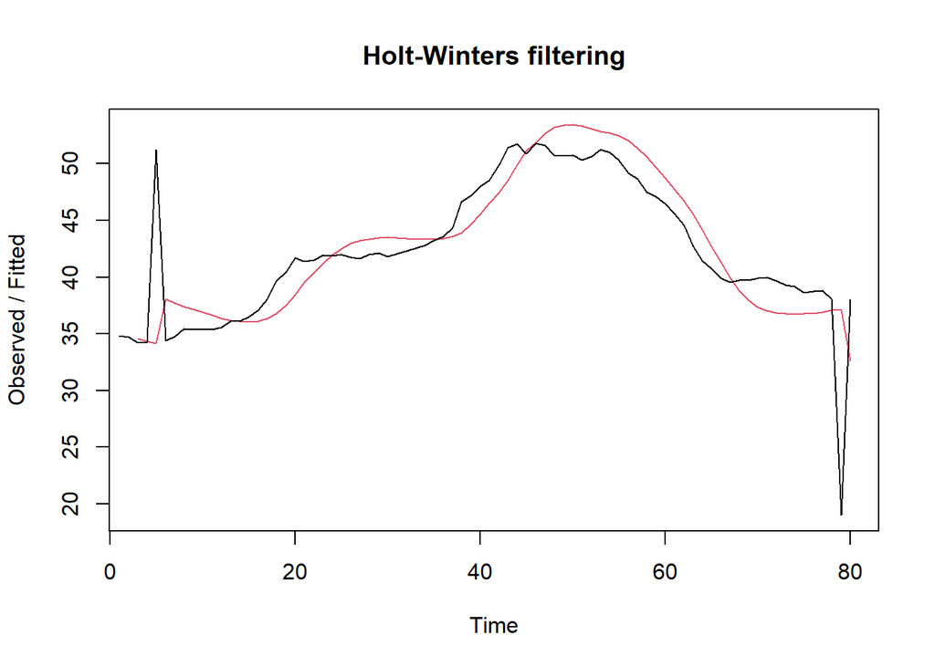

```r
#Lamda=0.2 dan gamma=0.2
des.1<- HoltWinters(train.ts, gamma = FALSE, beta = 0.2, alpha = 0.2)
plot(des.1)
```

```r
#ramalan
ramalandes1<- forecast(des.1, h=20)
ramalandes1
```

```
##     Point Forecast     Lo 80    Hi 80      Lo 95    Hi 95
##  81       32.99519 28.510483 37.47989 26.1364246 39.85395
##  82       32.31798 27.705929 36.93004 25.2644555 39.37151
##  83       31.64078 26.860837 36.42073 24.3304873 38.95108
##  84       30.96358 25.972848 35.95431 23.3309151 38.59624
##  85       30.28638 25.041000 35.53175 22.2642649 38.30849
##  86       29.60917 24.065531 35.15282 21.1309026 38.08745
##  87       28.93197 23.047605 34.81634 19.9326089 37.93134
##  88       28.25477 21.989013 34.52053 18.6721213 37.83742
##  89       27.57757 20.891901 34.26324 17.3527218 37.80242
##  90       26.90037 19.758556 34.04218 15.9779100 37.82282
##  91       26.22316 18.591259 33.85507 14.5511725 37.89516
##  92       25.54596 17.392185 33.69974 13.0758360 38.01609
##  93       24.86876 16.163352 33.57417 11.5549871 38.18253
##  94       24.19156 14.906598 33.47652  9.9914369 38.39168
##  95       23.51436 13.623577 33.40513  8.3877154 38.64100
##  96       22.83715 12.315769 33.35854  6.7460841 38.92822
##  97       22.15995 10.984489 33.33541  5.0685564 39.25135
##  98       21.48275  9.630908 33.33459  3.3569230 39.60857
##  99       20.80555  8.256069 33.35502  1.6127765 39.99832
## 100       20.12834  6.860898 33.39579 -0.1624636 40.41915
```

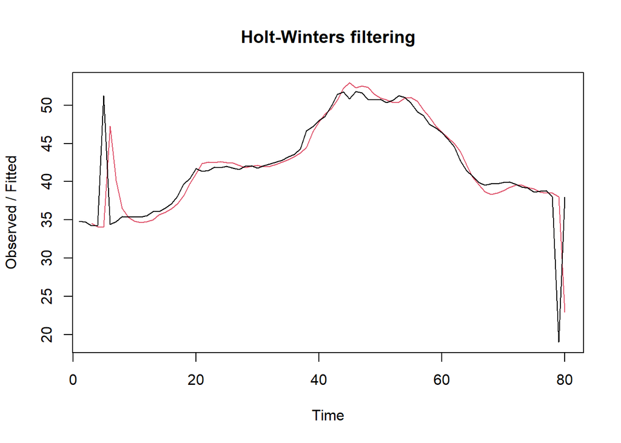

```r
#Alpha=0.6 dan beta=0.3
des.2<- HoltWinters(train.ts, gamma = FALSE, beta = 0.3, alpha = 0.6)
plot(des.2)
```

```r
#ramalan
ramalandes2<- forecast(des.2, h=20)
ramalandes2
```

```
##     Point Forecast       Lo 80    Hi 80       Lo 95    Hi 95
##  81       31.04040  26.1505760 35.93022  23.5620606 38.51874
##  82       30.09770  23.8962981 36.29911  20.6134728 39.58193
##  83       29.15501  21.3772699 36.93275  17.2599841 41.05003
##  84       28.21231  18.6432423 37.78138  13.5776824 42.84694
##  85       27.26962  15.7271518 38.81208   9.6169395 44.92230
##  86       26.32692  12.6511475 40.00270   5.4116295 47.24222
##  87       25.38423   9.4308134 41.33764   0.9855862 49.78287
##  88       24.44153   6.0776631 42.80540  -3.6435821 52.52665
##  89       23.49884   2.6005828 44.39709  -8.4622849 55.45996
##  90       22.55614  -0.9933132 46.10560 -13.4596419 58.57193
##  91       21.61345  -4.6981571 47.92505 -18.6266790 61.85357
##  92       20.67075  -8.5089913 49.85050 -23.9558145 65.29732
##  93       19.72806 -12.4215460 51.87766 -29.4405178 68.89663
##  94       18.78536 -16.4320847 54.00281 -35.0750748 72.64580
##  95       17.84267 -20.5372959 56.22263 -40.8544209 76.53975
##  96       16.89997 -24.7342130 58.53416 -46.7740191 80.57396
##  97       15.95728 -29.0201548 60.93471 -52.8297689 84.74432
##  98       15.01458 -33.3926796 63.42184 -59.0179359 89.04710
##  99       14.07189 -37.8495495 65.99332 -65.3350975 93.47887
## 100       13.12919 -42.3887019 68.64708 -71.7780993 98.03648
```

Selanjutnya jika ingin membandingkan plot data latih dan data uji adalah sebagai berikut.

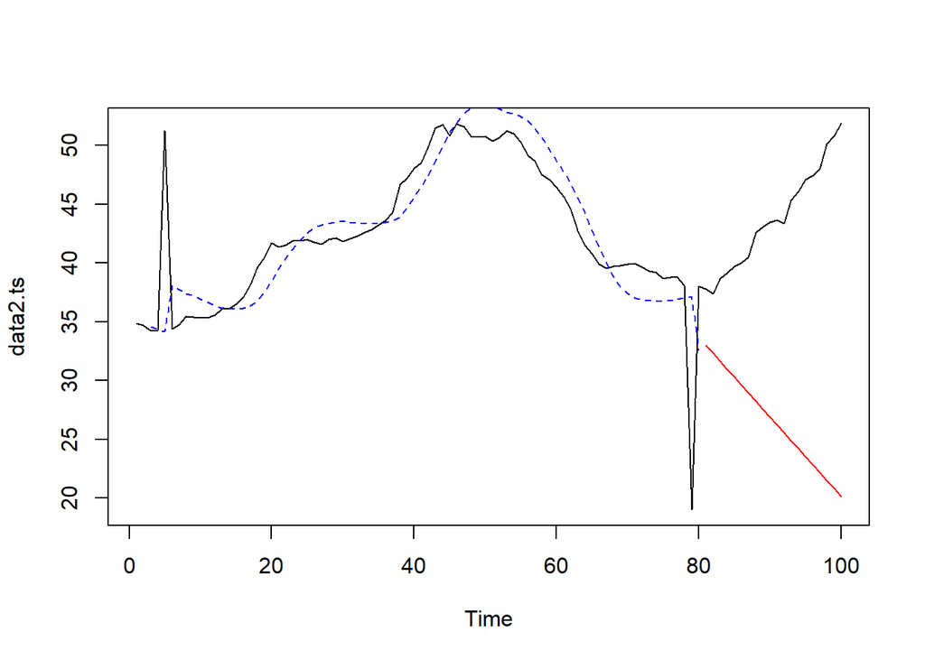

```r
plot(data2.ts)
lines(des.1$fitted[,1], lty=2, col="blue")
lines(ramalandes1$mean, col="red")
```

Untuk mendapatkan nilai parameter optimum dari DES, argumen alpha dan beta dapat dibuat NULL seperti berikut.

```r
#Lamda dan gamma optimum
des.opt<- HoltWinters(train.ts, gamma = FALSE)
des.opt
```

```
## Holt-Winters exponential smoothing with trend and without seasonal component.
##
## Call:
## HoltWinters(x = train.ts, gamma = FALSE)
##
## Smoothing parameters:
##  alpha: 0.3285743
##  beta : 0.114319
##  gamma: FALSE
##
## Coefficients:
##         [,1]
## a 32.9290472
## b -0.7288979
```

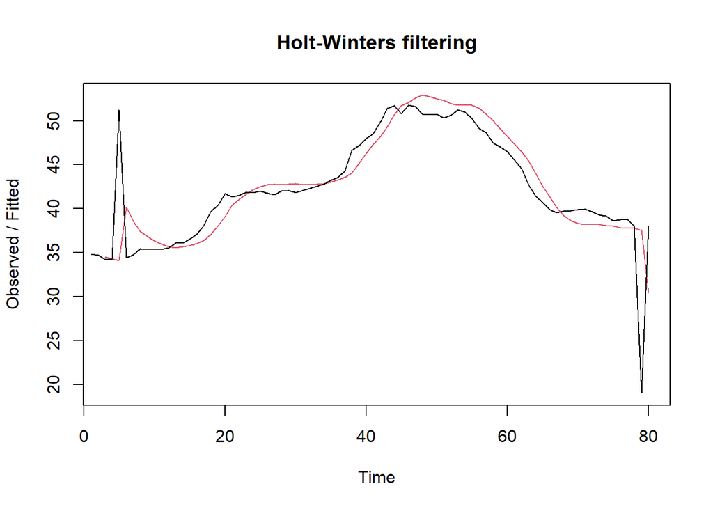

```r
plot(des.opt)
```

```r
#ramalan
ramalandesopt<- forecast(des.opt, h=20)
ramalandesopt
```

```
##     Point Forecast     Lo 80    Hi 80      Lo 95    Hi 95
##  81       32.20015 27.843169 36.55713 25.5367224 38.86358
##  82       31.47125 26.831413 36.11109 24.3752304 38.56727
##  83       30.74235 25.780311 35.70440 23.1535650 38.33114
##  84       30.01346 24.691978 35.33493 21.8749580 38.15195
##  85       29.28456 23.568750 35.00037 20.5429844 38.02613
##  86       28.55566 22.412987 34.69833 19.1612526 37.95007
##  87       27.82676 21.226943 34.42658 17.7332102 37.92031
##  88       27.09786 20.012699 34.18303 16.2620394 37.93369
##  89       26.36897 18.772134 33.96580 14.7506139 37.98732
##  90       25.64007 17.506922 33.77321 13.2014945 38.07864
##  91       24.91117 16.218544 33.60380 11.6169454 38.20540
##  92       24.18227 14.908304 33.45624  9.9989618 38.36558
##  93       23.45337 13.577351 33.32940  8.3493001 38.55745
##  94       22.72448 12.226697 33.22226  6.6695086 38.77944
##  95       21.99558 10.857237 33.13392  4.9609552 39.03020
##  96       21.26668  9.469764 33.06360  3.2248528 39.30851
##  97       20.53778  8.064983 33.01058  1.4622811 39.61328
##  98       19.80888  6.643526 32.97424 -0.3257947 39.94356
##  99       19.07999  5.205959 32.95401 -2.1385078 40.29848
## 100       18.35109  3.752794 32.94938 -3.9750761 40.67725
```

```r
#Akurasi Data Training
ssedes.train1<-des.1$SSE
msedes.train1<-ssedes.train1/length(train.ts)
sisaandes1<-ramalandes1$residuals
head(sisaandes1)
```

```
## Time Series:
## Start = 1
## End = 6
## Frequency = 1
## [1]        NA        NA -0.350000 -0.016000 17.101840 -3.687962
```

```r
mapedes.train1 <- sum(abs(sisaandes1[3:length(train.ts)]/train.ts[3:length(train.ts)])
                      *100)/length(train.ts)

akurasides.1 <- matrix(c(ssedes.train1,msedes.train1,mapedes.train1))
row.names(akurasides.1)<- c("SSE", "MSE", "MAPE")
colnames(akurasides.1) <- c("Akurasi lamda=0.2 dan gamma=0.2")
akurasides.1
```

```
##      Akurasi lamda=0.2 dan gamma=0.2
## SSE                       945.171133
## MSE                        11.814639
## MAPE                        5.587666
```

```r
ssedes.train2<-des.2$SSE
msedes.train2<-ssedes.train2/length(train.ts)
sisaandes2<-ramalandes2$residuals
head(sisaandes2)
```

```
## Time Series:
## Start = 1
## End = 6
## Frequency = 1
## [1]        NA        NA  -0.35000   0.17300  17.20106 -12.88391
```

```r
mapedes.train2 <- sum(abs(sisaandes2[3:length(train.ts)]/train.ts[3:length(train.ts)])
                      *100)/length(train.ts)

akurasides.2 <- matrix(c(ssedes.train2,msedes.train2,mapedes.train2))
row.names(akurasides.2)<- c("SSE", "MSE", "MAPE")
colnames(akurasides.2) <- c("Akurasi lamda=0.6 dan gamma=0.3")
akurasides.2
```

```
##      Akurasi lamda=0.6 dan gamma=0.3
## SSE                      1121.246133
## MSE                        14.015577
## MAPE                        4.129176
```

Berdasarkan hasil evaluasi pada data latih, kedua skenario DES dibandingkan menggunakan nilai SSE, MSE, dan MAPE. Skenario dengan nilai kesalahan yang lebih kecil menunjukkan hasil pemulusan yang lebih baik.

```r
#Akurasi Data Testing
selisihdes1<-ramalandes1$mean-testing$Harga
selisihdes1
```

```
## Time Series:
## Start = 81
## End = 100
## Frequency = 1
##  [1]  -4.804814  -5.032016  -7.009219  -8.136421  -9.413623 -10.390825
##  [7] -11.518027 -14.345229 -15.472432 -16.549634 -17.426836 -17.804038
## [13] -20.431240 -21.908442 -23.535645 -24.612847 -25.840049 -28.617251
## [19] -29.994453 -31.721656
```

```r
SSEtestingdes1<-sum(selisihdes1^2)
MSEtestingdes1<-SSEtestingdes1/length(testing$Harga)
MAPEtestingdes1<-sum(abs(selisihdes1/testing$Harga)*100)/length(testing$Harga)

selisihdes2<-ramalandes2$mean-testing$Harga
selisihdes2
```

```
## Time Series:
## Start = 81
## End = 100
## Frequency = 1
##  [1]  -6.759602  -7.252297  -9.494992 -10.887687 -12.430382 -13.673077
##  [7] -15.065773 -18.158468 -19.551163 -20.893858 -22.036553 -22.679248
## [13] -25.571943 -27.314638 -29.207333 -30.550028 -32.042723 -35.085418
## [19] -36.728113 -38.720808
```

```r
SSEtestingdes2<-sum(selisihdes2^2)
MSEtestingdes2<-SSEtestingdes2/length(testing$Harga)
MAPEtestingdes2<-sum(abs(selisihdes2/testing$Harga)*100)/length(testing$Harga)

selisihdesopt<-ramalandesopt$mean-testing$Harga
selisihdesopt
```

```
## Time Series:
## Start = 81
## End = 100
## Frequency = 1
##  [1]  -5.599851  -5.878749  -7.907647  -9.086544 -10.415442 -11.444340
##  [7] -12.623238 -15.502136 -16.681034 -17.809932 -18.738830 -19.167728
## [13] -21.846626 -23.375524 -25.054421 -26.183319 -27.462217 -30.291115
## [19] -31.720013 -33.498911
```

```r
SSEtestingdesopt<-sum(selisihdesopt^2)
MSEtestingdesopt<-SSEtestingdesopt/length(testing$Harga)
MAPEtestingdesopt<-sum(abs(selisihdesopt/testing$Harga)*100)/length(testing$Harga)

akurasitestingdes <-
  matrix(c(SSEtestingdes1,MSEtestingdes1,MAPEtestingdes1,SSEtestingdes2,MSEtestingdes2,
           MAPEtestingdes2,SSEtestingdesopt,MSEtestingdesopt,MAPEtestingdesopt),
         nrow=3,ncol=3)
row.names(akurasitestingdes)<- c("SSE", "MSE", "MAPE")
colnames(akurasitestingdes) <- c("des ske1","des ske2","des opt")
akurasitestingdes
```

```
##        des ske1    des ske2    des opt
## SSE  7282.45901 11316.28300 8301.16870
## MSE   364.12295   565.81415  415.05843
## MAPE   37.88436    47.86531   40.78332
```

Berdasarkan hasil evaluasi pada data uji, ketiga model DES, yaitu skenario 1, skenario 2, dan parameter optimum, dibandingkan menggunakan nilai SSE, MSE, dan MAPE. Model dengan nilai kesalahan yang paling kecil menunjukkan kemampuan peramalan yang lebih baik terhadap data uji.

## Perbandingan SES dan DES

```r
MSEfull <-
  matrix(c(MSEtesting1,MSEtesting2,MSEtestingopt,MSEtestingdes1,MSEtestingdes2,
           MSEtestingdesopt),nrow=3,ncol=2)
row.names(MSEfull)<- c("ske 1", "ske 2", "ske opt")
colnames(MSEfull) <- c("ses","des")
MSEfull
```

```
##               ses      des
## ske 1    83.61134 364.1230
## ske 2   113.84839 565.8142
## ske opt 122.40564 415.0584
```

# Evaluasi

## Evaluasi Model

Berdasarkan hasil pemodelan dan evaluasi yang telah dilakukan, metode SMA, DMA, SES, dan DES dibandingkan menggunakan ukuran akurasi SSE, MSE, RMSE, dan MAPE pada data uji. Pada metode Moving Average, SMA menggunakan N=8, sedangkan DMA juga menggunakan N=8. Hasil evaluasi menunjukkan bahwa metode SMA memberikan kinerja yang lebih baik dibandingkan DMA pada data uji. Selanjutnya, pada metode Exponential Smoothing, dilakukan perbandingan beberapa nilai parameter dan parameter optimum untuk metode SES dan DES. Pemilihan model terbaik dilakukan berdasarkan nilai kesalahan pada data uji, dengan mempertimbangkan bahwa nilai MSE, RMSE, dan MAPE yang lebih kecil menunjukkan hasil peramalan yang lebih baik.